# Using Course Schedulizer

To Create a Class Schedule for a Department

# Two Approaches

## Import or Start from Scratch?

There are two ways to create a schedule for a new academic year:

1. Start from a past schedule and modify it, or
2. Build the schedule from scratch in the Course Schedulizer.

Typically option 1 saves a lot of time unless your schedule is undergoing dramatic changes.

## Getting A Previous Schedule

You can download a previous schedule from https://reports.calvin.edu/Reports/report/Departmental%20Reports/Course%20Section%20Report. Fill in the desired terms and department, view the report, and then download it **as a CSV**.

[figure not shown]

The file will be called something like `Course Section Report.csv` and will probably be in the default location where your browser uses for downloads.

**Do not export your schedule from Workday.** The Workday report uses a different format that Course Schedulizer does not know how to import.

- Importing from Workday is on the list of feature requests.

# Getting Started with Course Schedulizer

## Launching Course Schedulizer

Navigate in a browser to https://senior-knights.github.io/course-schedulizer/#/

The first time you do this, you will see

[figure not shown]

You can view the demo or explore the help if you like, but eventually you will be ready to press either

1. Import Schedule (if you just downloaded a schedule to start from), or
2. Add Section (if you are building from scratch).

## Importing a Previous Schedule

If you have a saved schedule (either one you exported from reports.calvin.edu or one that you previously saved in Course Schedulizer), you can import it by clicking the button and navigating to the file on your computer.

[figure not shown]

## Inspecting Your Schedule

Once a schedule is loaded, you can inspect the schedule in one of several views by selecting the tab you are interested in. Here is the **Room Schedule view**, colored by instructor:

[figure not shown]

You may need to zoom in or out or scroll to get a good view.

### Conflicts

Notice that a few classes are outlined in red. These are being flagged as conflicts. You can see all your conflicts in the **Conflicts view**:

[figure not shown]

### Non-standard meeting patterns

Sections outlined in orange represent non-standard meeting patterns. **The use of non-standard meeting patterns is highly discouraged, so be sure to include a note explaining why you are not following the standard schedule.**

### Facutly Load Tallies

The **Teaching Loads view** tallies up teaching loads from the courses. You can also add non-teaching load for things like CRFs, administrative duties, etc.

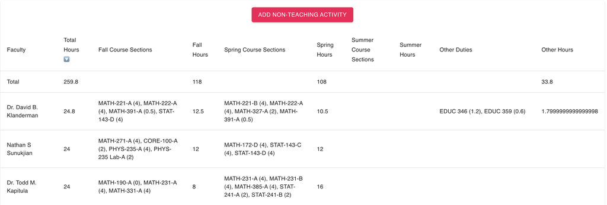

## Exporting your schedule

While your browser will probably cache your work, it is a good idea to save your progress. The menu in the upper left corner gives you this option:

[figure not shown]

Choose **Export CSV**, and your schedule will be saved to your computer. The file name will include a time stamp so you can tell when it was generated.

### Hand editing your schdedule (Use with caution!)

It is possible to edit this file by hand (in Excel, for example). But you need to be careful not to corrupt the format of the file. The file contains some redundant information, some of which is ignored when you import the schedule. This is primarily useful in two situations:

- You want to make a systematic change to a number of courses.
  - Example: Putting all your courses into groups
  - Example from last year: moving all 50-minute classes to 65 minutes
- You need to do something with your schedule that Schedulizer doesn’t handle.  
  (Drop me a note about it as well, so we can consider adding this to our to-do list.)

**Advice**:

- Save your schedule with a new name before editing so that if something goes wrong, you can always revert to your previously saved version.
- Don’t edit the file that you get from `reports.calvin.edu`. Instead, import that file into Schedulizer, export to CSV, and edit the exported file. Schedulizer will make some changes to the file, and it is best to work from this modified file.

Once you have made your edits, you can upload the edited file and resume working in Course Schedulizer.

# Adding and Modifying Sections

At this point you either have a draft schedule (likely with many edits to make) or an empty schedule waiting for some sections to be added.

The **Add a Section** button on the initial screen or the **+** off to the right in the gray bar can be used to bring up the menu for adding a section.

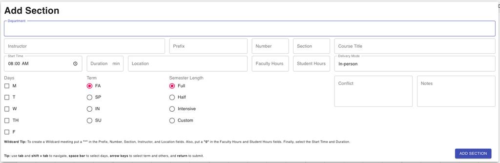

Just fill in the information and click **Add Section**.

> Note: If you choose a half-semester course, you will be prompted to indicate whether it is a first half or second half course. A similar thing happens for the intensive classes.

Some information (like Course Title and Notes) can be left blank and filled in later (or not at all).

- Note: The registrar requests that you **assign rooms to each in-person course**. Apparently some chairs did not do this last year. There may be some shifting of room assignments after you submit your schedule, but it is helpful for the registrar’s office to begin with draft room assignments, and chairs typically know which rooms work best for which sections.

To edit a section, just click on that section in one of the views to bring up the section editor and make your modifications. You can use those modifications to update the existing section or to create a new section.

In particular, if you have a number of similar sections to add, you can create one and then use it as a template for creating the others. This saves a lot of time. Just use **Add New Section** button instead of the **Update Section** button.

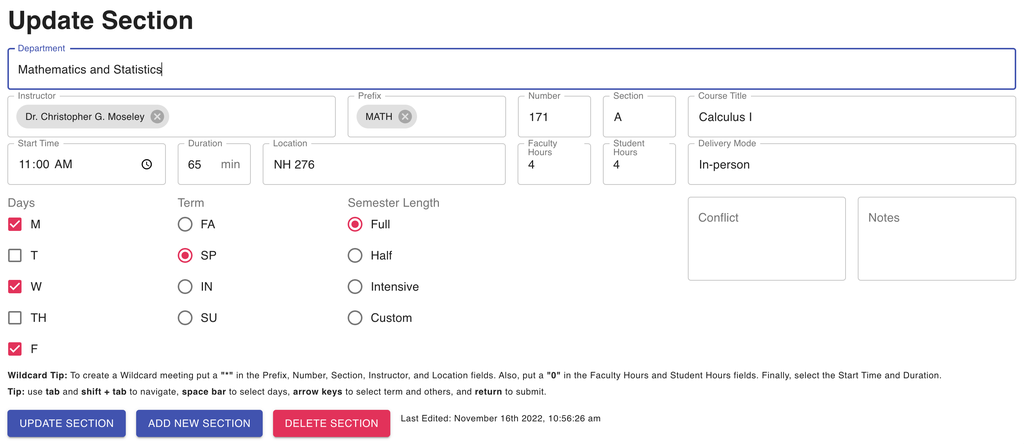

Most of these fields are self-explanatory, but one of these is new in Workday:

- Delivery Method should be one of: **In-person**, **Online synchronous**, **Online asynchronous**, or **Hybrid**.
  - If those categories don’t fit your course, contact Student Success about what label you should use.

## Notes

You can add text notes to sections. While you are developing your schedule, these can be used to remind yourself of why you have done certain things, things that still need attention, etc. These notes will also be communicated to the registrar’s office, so you can use them to communicate important information to that office as well.

> In particular, if you discover something you can’t get Course Schedulizer to do, do the best you can and add a note to let the registrar know what you mean.

# Tips and Tricks

## Sharing your schedule with others

If you want to share your schedule with others, there are two ways to do that:

1. You can email them the CSV that you have exported.

   This works just like sending someone a Word document. Recipients can **open the schedule using the Couse Schedulizer** (not Excel). They can even edit the schedule, but that won’t change your copy of the schedule.  
   Of course, they can email their changed vesion back to you if they want to make suggestions.
2. If you can post your CSV in a public place, you can give people a link that will let people load your schedule with one click.

   You could use something like dropbox or google drive to share your CSV file. Once you do that, you can use a link like this one to share your schedule with others:

   https://senior-knights.github.io/course-schedulizer/#/?csv=https://rpruim.github.io/Schedulizer/data/MathStat-2023-24-current.csv

   Just edit the part after `?csv=` and replace it with your URL.

   Note: The CSV file must be accessible to the recipients, so make sure you set permissions so that anyone with the link can access the file.

## Using groups

A recent update of Course Schedulizer allows you to enter information into a “Group” field when creating or modifying a section. You can color your schedule by these groups. If there are groups of courses that you would like to be able to identify in this way, just add the groups data and you should be all set.

## Viewing partial semester courses

Course Schedulizer you to select which portion of a semester to show (Full, First Half, Second Half, A, B, C, or D). If you select, for example, B, then you will see only Full, First Half, and Intensive B classes, since all of those meet durring the intensive B session.

## Multiple meeting patterns for one course

The app does not currently allow you to edit multiple meeting patterns for one section. This is on our wish list but likely won’t be available this year. In the meantime, here is a work-around:

1. Schedule the section for one meeting pattern.
   1. Use the full number of faculty and student hours for this section.
   2. Add a note indicating that there are additional meeting patterns.
2. Edit that section and save as a new section:
   1. Set the faculty and student hours to 0
   2. Schedule the other meeting pattern
   3. Click to **ADD** a new section

This will result in two rows of data for this course, one for each meeting pattern. This isn’t ideal, but it will work for the moment.

## Adding another schedule

If you have a schedule from another department or program, you can add it to your schedule using “Add Schedule” rather than “Import new schedule”. This will allow you to view schedules from multiple departments together.

On our to-do list is a dialog that will allow you export just the part of the schedule associated with one department, but for now, once you do the add, the two schedules are merged and can’t be separated in the app. But you can go to the CSV and remove rows according to the department column. Or revert to a saved version of your schedule that did not include the additional course sections.

If you and the other chair coordinate your use of the Group field, you can use that to toggle your view of the schedule.

## Showing chapel, Department meetings, etc.

Here’s a way that you can have chapel break show up on your department schedule view:

1. Add a new section to your schedule
2. Enter * for Instructor, Prefix, Number, Section, and Location. (For something like a department meeting, enter the location if you are using a classroom.)
3. Enter the days, time, and duration.
4. Enter Faculty Hours as 0 (so it doesn’t contribute to anyone’s load).
5. Save.

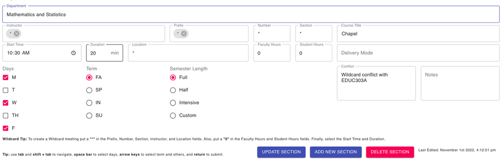

This shows up nicely in the department view:

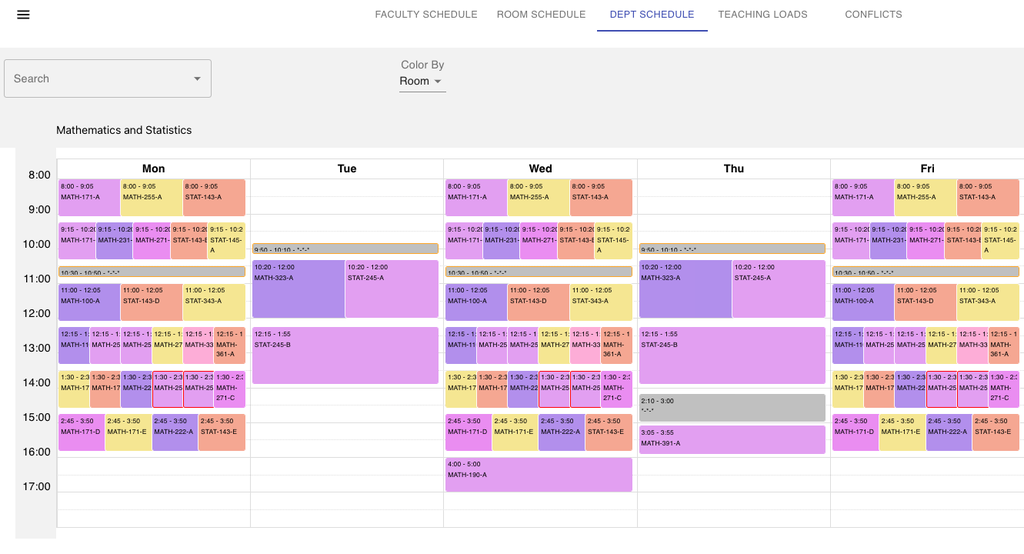

In the other views, * will show up as an instructor and as room, which isn’t as useful. And it will list in the department loads as 0 hours. **We have a feature request to do this in a better way – stay tuned.**

These “wildcard” items will conflict with any course scheduled at the same time.

# Future Development

Course Schedulizer is being expanded and improved by some senior computer science students. If notice bugs or have suggestions for improvement, please let us know.

# Submitting your schedule

The CSV file that you export from Course Schedulizer can be submitted to your dean (and eventually to Student Success). It contains all the information they need to approve your schedule and get your schedule into Workday. Entering the schedule into Workday is still a manual process, so you will likely need to do a schedule review to make sure that the schedule as entered into Workday matches what you intended. (Eventually, we hope to automate some of this process.)